# What Bayes factor should you expect?

Martin Papenberg

December 18, 2017

The usage of Bayesian statistics, and in particular the usage of Bayes factors is on the rise in Psychology. Bayes factors have been advocated as an alternative to statistical null hypothesis significance testing relying on *p*-values. They quantify the relative evidence that data provide for two different hypotheses. As a prominent application in Psychology, several “default” Bayes factors have been proposed that compare an alternative hypothesis assuming an effect (e.g. there is a difference between two means) to a null hypothesis assuming no effect (e.g. there is no difference between two means). Such Bayes factors quantify how much better a specified alternative hypothesis describes the data than the null hypothesis.[^1] For example, when obtaining a Bayes factor of size 5, the data are 5 times more likely under the alternative hypothesis than under the null hypothesis; you may say that the data favor the alternative hypothesis by a factor of 5.[^2]

The general appraisal of Bayes factors seems to reach from “*will save statistical inference in Psychology from evil p-values*” to “*dangerous statistic that will lead to bogus interpretations of data*”. However one may think of Bayes factors, given their increasing occurrence in Psychological research it is probably useful to know how they behave under different settings. In this post I therefore describe what Bayes factors you should expect when varying the sample size and effect size. As is usually done, I will stick to the example of the independent sample *t*-test that compares two means, and I will use the “default” Bayes factor proposed by Rouder, Speckman, Sun, Morey, & Iverson (2009), which is implemented in the R package BayesFactor (Morey & Rouder, 2015).[^3] Hence, my evaluation of Bayes factors is limited to this specific model.

## The distribution of Bayes factors

The following plot illustrates the distribution of the default Bayes factors for different sample sizes and effect sizes *d* = 0 (meaning that the null hypothesis is true), *d* = 0.2 (a small effect), *d* = 0.5 (a medium effect) and *d* = 0.8 (a large effect). Note that null and small effect share the same scaling of the y-axis; medium and large effect also share the same scaling but this scaling is different to the scaling of the y-axis of null and small effect (simply because the values of the Bayes factor differ very strongly by effect size). The data were generated in a simulation assuming normally distributed scores (*M* = 0 for one group and *M* = *d* for the other group; *SD* = 1 for both groups).

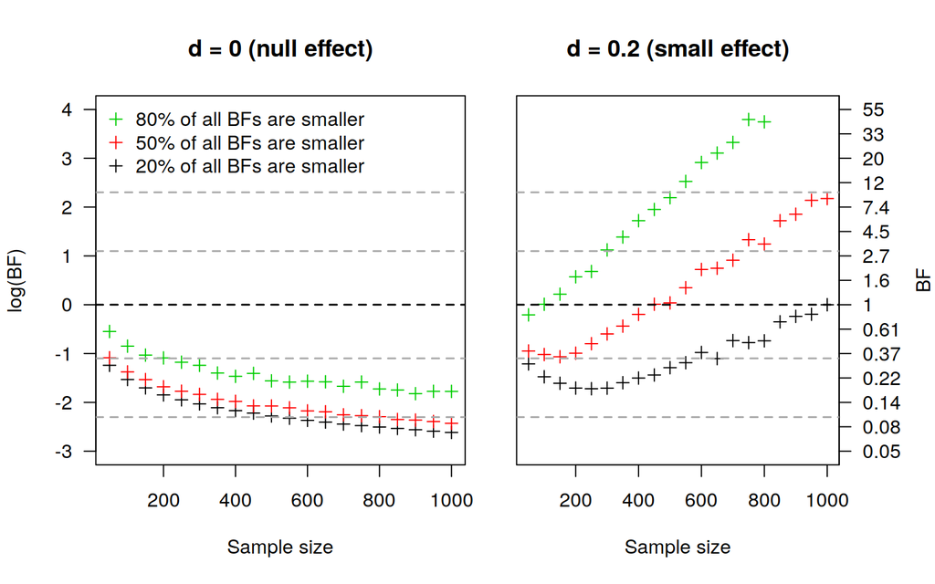

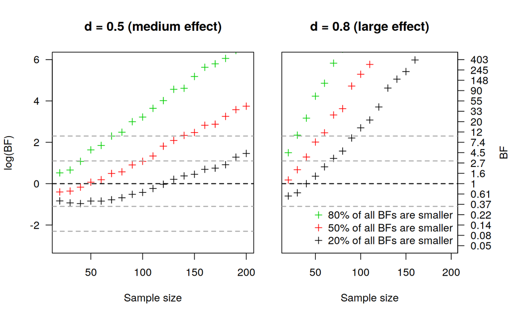

The code used to produce this simulation can be retrieved from here and here. This code has also been implemented into the `R` package bayesEd.

Last update: 2019-11-18

# References

Morey, R. D., & Rouder, J. N. (2015). *BayesFactor: Computation of bayes factors for common designs*. Retrieved from https://CRAN.R-project.org/package=BayesFactor

Rouder, J. N., Speckman, P. L., Sun, D., Morey, R. D., & Iverson, G. (2009). Bayesian t tests for accepting and rejecting the null hypothesis. *Psychonomic Bulletin & Review*, *16*(2), 225–237.

[^1]: In general it is not necessary that one of the competing hypotheses is a null hypothesis.
[^2]: However, you may not say that the alternative hypothesis is 5 times more likely than the null hypothesis.
[^3]: This is also the Bayes factor used in the statistics program JASP when doing the Bayesian *t*-test.